# Port investments as policy tools

Katja Kalkschmied

2024-07-09

# Difference in Differences: cross-port variation in trade with ports in Lithuania

Aggregation of group time treatment effects, treatment in period 100

Dependent variable: Total throughput with Lithuania in thousand TEU

|  | Never treated unconditional | Never treated 95% CI | Never treated conditional | Never treated 95% CI | Not yet treated conditional | Not yet treated 95% CI |
| --- | --- | --- | --- | --- | --- | --- |
| simple average | -2,193 | [-4,559, 174] | -1,855* | [-3,564; -146] | -1,855* | [-3,156; -554] |
| Gdynia | -10,851* | [-13,397, -8,306] | -11,104* | [-13,853; -8,355] | -11,104* | [-13,853; -8,355] |
| by group: |  |  |  |  |  |  |
| Antwerpen | 339 | [-1,415, 2,092] | 4,776* | [2,071; 7,482] | 4,776* | [2,823; 6,730] |
| Barcelona | -289 | [-3,419, 2,841] | -776 | [-3,329; 1,778] | -776 | [-3,257; 1,706] |
| Valencia | -471 | [-3,288, 2,345] | 228 | [-2,646; 3,103] | 228 | [-1,672; 2,129] |
| Dunkerque | -2,375 | [-13,873, 9,123] | 1,625 | [-10,523; 13,774] | 1,625 | [-4,675; 7,926] |
| Le Havre | 5,451* | [3,462, 7,439] | 6,518* | [3,837; 9,198] | 6,518* | [3,837; 9,198] |
| Nantes Saint Nazaire | -536 | [-6,724, 5,652] | -364 | [-5,172; 4,445] | -364 | [-5,172; 4,445] |
| Piraeus | 166 | [-2,148, 2,480] | 1,672 | [-297; 3,641] | 1,672 | [-297; 3,641] |
| Marsaxlokk | -315 | [-3,003, 2,374] | -361 | [-3,445; 2,724] | -361 | [-3,722; 3,001] |
| Rotterdam | -1,775 | [-4,592, 1,041] | -2,165^{x} | [-5,115; 785] | -2,165 | [-5,115; 785] |

Stars indicate that the confidence interval does not include zero.

```
##   average_container_sample
## 1                 2085.029
```

```
##   average_container_gdynia
## 1                     5911
```

Comparing trade with Lithuanian ports of Chinese treated ports with non-Chinese treated ports after the opening of the diplomatic council with Taiwan in September 2021, we do see a small negative bias of Chinese treated ports. This, however, is solely driven by the port of Gdynia. The ports of Antwerpen and Le Havre show a positive effect. The effect of Antwerpen is suspicious/problematic since our recording for Antwerpen stops at 100. So there is only one treated data point for Antwerpen. We have to recheck what to do with this. Since we have recordings for Antwerp-Grugges from 101-107, we may consider merging them into one time series.

Difference to previous estimation tasks: I drew new information from Eurostat to increase the period from 107 (2023, Q3) to 109 (2024, Q1) to have more post-treatment observations.

# Difference in Differences: check if Gdynia effect is a general effect

Aggregation of group time treatment effects, treatment in period 100

Dependent variable: Total throughput with all nationality ports in thousand TEU

|  | Never treated unconditional | Never treated 95% CI | Never treated conditional | Never treated 95% CI | Not yet treated conditional | Not yet treated 95% CI |
| --- | --- | --- | --- | --- | --- | --- |
| simple average | -56,424* | [-68,280, -44,569] | -18,238* | [-29,227; -7,248] | -18,238* | [-29,076; -7,400] |
| Piraeus | -127,988*^{x} | [-144,997, -110,979] | -66,739* | [-108,062; -25,416] | -66,739* | [-103,220; -30,258] |
| Thessaloniki | 6,256 | [-18,933, 31,444] | 3,086 | [-22,439; 28,612] | 3,086 | [-28,944; 35,117] |
| Genova | 4,902 | [-29,171, 38,975] | 56,693* | [23,890; 89,496] | 56,693* | [17,613; 95,773] |
| Marsaxlokk | -3,735 | [-38,931, 31,461] | 30,250 | [-1,831; 62,330] | 30,250 | [-8,041; 68,540] |
| Amsterdam | -91 | [-18,216, 18,033] | -5,157 | [-43,084; 32,771] | -5,157 | [-43,084; 32,771] |
| Moerdijk | 3,788 | [-14,643, 22,220] | 6,081 | [-25,262; 37,423] | 6,081 | [-31,264; 43,425] |
| Rotterdam | -410,772*^{x} | [-436,471, -385,074] | -184,323* | [-224,013; -144,633] | -184,323* | [-217,510; -151,135] |
| Gdynia | -43,228* | [-68,926, -17,529] | -32,942 | [-70,707; 4,822] | -32,942* | [-64,412; -1,473] |
| Ambarli | 24,762*^{x} | [414, 49,111] | 62,159* | [32,647; 91,671] | 62,159* | [22,953; 101,366] |
| by group: |  |  |  |  |  |  |
| Antwerpen | -51,319*^{x} | [-62,245, -40,393] | 935^{x} | [-11,358; 13,227] | 935^{x} | [-21,732; 23,602] |
| Zeebrugge | -5,785 | [-18,270, 6,700] | -2,943 | [-29,997; 24,111] | -2,943 | [-29,880; 23,993] |
| Barcelona | -71,355* | [-84,696, -58,013] | -27,556 | [-56,557; 1,444] | -27,556 | [-60,413; 5,300] |
| Bilbao | -9,710 | [-34,262, 14,841] | -10,042 | [-47,822; 27,738] | -10,042 | [-47,822; 27,738] |
| Valencia | -154,050*^{x} | [-172,437, -135,662] | -80,608* | [-119,742; -41,474] | -80,608* | [-113,456; -47,760] |
| Dunkerque | 20,949* | [1,685, 40,212] | 16,265 | [-21,315; 53,844] | 16,265 | [-21,047; 53,576] |
| Le Havre | 14,165 | [-1,214, 29,544] | 33,740* | [9,752; 57,727] | 33,740* | [6,418; 61,061] |
| Marseille | -54,155* | [-81,405, -26,905] | -59,383* | [-96,773; -21,993] | -59,383* | [-99,859; -18,907] |
| Nantes Saint Nazaire | -8,155 | [-46,856, 30,546] | -11,918 | [-40,371; 16,536] | -11,918 | [-38,952; 15,117] |

Stars indicate that the confidence interval does not include zero.

When looking at changes of the treated ports with all trading partners around period 100 (September 2021) number of Chinese ports have experienced a decline in trade as compared to untreated ports. I think this is still a covid effect, that has especially hit ports engaged in international trade which are the ports in which Chinese invested. I guess international container shipments were still hurt eventually substituted by intraregional trade.

Also, Gdynia experienced a decrease of its overall container shipments more than a comparable untreated port.

# Difference in Differences: check if general Gdynia effect at period stays if we exclude shipments to Lithuania

Aggregation of group time treatment effects, treatment in period 100

Dependent variable: Total throughput with all nationality ports but Lithuania in thousand TEU

|  | Never treated unconditional | Never treated 95% CI | Never treated conditional | Never treated 95% CI | Not yet treated conditional | Not yet treated 95% CI |
| --- | --- | --- | --- | --- | --- | --- |
| simple average | -55,529* | [-67,374, -43,685] | -17,711* | [-28,224; -7,198] | -17,711* | [-28,205; -7,216] |
| Piraeus | -128,284*^{x} | [-145,273, -111,295] | -68,320* | [-108,875; -27,764] | -68,320* | [-104,525; -32,114] |
| Thessaloniki | 6,235 | [-18,872, 31,342] | 3,082 | [-22,018; 28,182] | 3,082 | [-28,688; 34,852] |
| Genova | 4,940 | [-27,031, 36,911] | 56,323* | [24,118; 88,529] | 56,323* | [17,569; 95,078] |
| Marsaxlokk | -3,676 | [-35,076, 27,723] | 29,849 | [-1,647; 61,345] | 29,849 | [-8,128; 67,827] |
| Amsterdam | -53 | [-18,216, 18,109] | -5,045 | [-42,664; 32,573] | -5,045 | [-42,664; 32,573] |
| Moerdijk | 3,666 | [-14,760, 22,091] | 5,972 | [-24,800; 36,745] | 5,972 | [-31,069; 43,013] |
| Rotterdam | -409,259*^{x} | [-434,916, -383,602] | -183,560* | [-222,926; -144,194] | -183,560* | [-216,143; -150,977] |
| Gdynia | -32,638* | [-58,295, -6,982] | -22,198 | [-59,530; 15,134] | -22,198 | [-53,095; 8,699] |
| Ambarli | 24,797*^{x} | [410, 49,184] | 62,333* | [33,327; 91,339] | 62,333* | [23,577; 101,089] |
| by group: |  |  |  |  |  |  |
| Antwerpen | -51,218*^{x} | [-61,963, -40,474] | -3,336^{x} | [-14,625; 7,953] | -3,336^{x} | [-24,809; 18,137] |
| Zeebrugge | -5,503 | [-17,820, 6,813] | -2,726 | [-29,084; 23,633] | -2,726 | [-28,955; 23,503] |
| Barcelona | -71,318* | [-84,560, -58,076] | -28,069 | [-56,554; 417] | -28,069 | [-60,346; 4,209] |
| Bilbao | -9,684 | [-34,262, 14,893] | -10,497 | [-47,845; 26,850] | -10,497 | [-47,845; 26,850] |
| Valencia | -153,840*^{x} | [-172,042, -135,638] | -81,043* | [-119,851; -42,236] | -81,043* | [-113,293; -48,794] |
| Dunkerque | 21,582* | [3,183, 39,981] | 16,727 | [-20,423; 53,876] | 16,727 | [-20,281; 53,734] |
| Le Havre | 9,154 | [-6,083, 24,390] | 27,300* | [3,519; 51,081] | 27,300* | [696; 53,904] |
| Marseille | -54,056* | [-81,405, -26,706] | -59,853* | [-97,415; -22,292] | -59,853* | [-99,679; -20,028] |
| Nantes Saint Nazaire | -8,058 | [-46,923, 30,806] | -11,600 | [-41,100; 17,901] | -11,600 | [-38,695; 15,496] |

Stars indicate that the confidence interval does not include zero.

The negative effect for Gdynia in general trade with its partners becomes insignificant when we omit ports in Lithuania. Hence, reductions in trade with Lithuania mattered for the overall trade development of Gdynia.

# Difference in Differences: check if Gdynia effect holds for trade with Germany

Aggregation of group time treatment effects, treatment in period 100

Dependent variable: Total throughput with German ports in thousand TEU

|  | Never treated unconditional | Never treated 95% CI | Never treated conditional | Never treated 95% CI | Not yet treated conditional | Not yet treated 95% CI |
| --- | --- | --- | --- | --- | --- | --- |
| simple average | -3,912 | [-23,941, 16,117] | -18,796* | [-28,242; -9,351] | -18,796* | [-27,443; -10,149] |
| Marsaxlokk | -1,535 | [-10,474, 7,404] | -17,760* | [-29,015; -6,506] | -17,760* | [-25,844; -9,676] |
| Moerdijk | -1,744 | [-12,968, 9,480] | -14,985* | [-26,971; -2,999] | -14,985* | [-29,200; -770] |
| Rotterdam | -10,906*^{x} | [-15,459, -6,352] | -78,476*^{x} | [-90,508; -66,443] | -78,476*^{x} | [-91,101; -65,850] |
| Gdynia | -8,648 | [-18,759, 1,464] | -10,306 | [-21,393; 780] | -10,306 | [-21,393; 780] |
| Ambarli | -4,581 | [-14,693, 5,531] | -15,488 | [-86,929; 55,953] | -15,488* | [-26,840; -4,136] |
| by group: |  |  |  |  |  |  |
| Antwerpen | -11,582* | [-18,297, -4,867] | -11,450* | [-20,559; -2,341] | -11,450* | [-20,559; -2,341] |
| Zeebrugge | -1,207 | [-14,021, 11,607] | -1,380 | [-4,971; 2,212] | -1,380 | [-10,374; 7,615] |
| Barcelona | -1,203 | [-9,848, 7,443] | -19,929* | [-31,799; -8,060] | -19,929* | [-31,336; -8,523] |
| Valencia | -3,387 | [-13,499, 6,724] | -18,903* | [-30,864; -6,942] | -18,903* | [-30,397; -7,410] |
| Dunkerque | 9 | [-10,103, 10,120] | 6,841 | [-4,232; 17,915] | 6,841 | [-4,208; 17,891] |
| Le Havre | 6,142* | [3,337, 8,947] | 6,114 | [-329; 12,556] | 6,114 | [-2,956; 15,183] |
| Nantes Saint Nazaire | -66 | [-3,899, 3,767] | -404 | [-9,228; 8,420] | -404 | [-5,572; 4,764] |
| Piraeus | -5,447 | [-15,305, 4,412] | -15,834* | [-25,628; -6,041] | -15,834* | [-28,128; -3,541] |
| Thessaloniki | -416 | [-8,579, 7,747] | 2,103 | [-4,800; 9,007] | 2,103 | [-7,816; 12,023] |

Stars indicate that the confidence interval does not include zero.

# Difference in Differences: check if Gdynia effect holds for trade with Latvia

Aggregation of group time treatment effects, treatment in period 100

Dependent variable: Total throughput with Latvian ports in thousand TEU

|  | Never treated unconditional | Never treated 95% CI | Never treated conditional | Never treated 95% CI | Not yet treated conditional | Not yet treated 95% CI |
| --- | --- | --- | --- | --- | --- | --- |
| simple average | -728 | [-5,720, 4,264] | 238 | [-2,333; 2,810] | 238 | [-2,559; 3,036] |
| Marsaxlokk | -1,232 | [-11,778, 9,314] | -1,865* | [-3,489; -241] | -1,865 | [-3,878; 149] |
| Rotterdam | 163 | [-2,438, 2,764] | 2,813^{x} | [-9,719; 15,345] | 2,813^{x} | [-9,719; 15,345] |
| Gdynia | 832 | [-12,950, 14,614] | -751 | [-2,661; 1,159] | -751 | [-12,609; 11,108] |
| by group: |  |  |  |  |  |  |
| Antwerpen | -3,790 | [-7,594, 13] | -8,676* | [-9,814; -7,539] | -8,676*^{x} | [-10,878; -6,475] |
| Zeebrugge | -901 | [-4,705, 2,902] | -558 | [-2,718; 1,602] | -558 | [-2,718; 1,602] |
| Barcelona | -1,219 | [-14,776, 12,338] | -164 | [-12,368; 12,041] | -164 | [-12,368; 12,041] |
| Bilbao | -1,523 | [-8,487, 5,442] | 845 | [-7,209; 8,899] | 845 | [-7,209; 8,899] |
| Valencia | -1,255 | [-3,856, 1,346] | 646 | [-11,723; 13,016] | 646 | [-11,723; 13,016] |
| Le Havre | -504 | [-3,715, 2,707] | -1,692 | [-3,927; 542] | -1,692 | [-3,927; 542] |
| Marseille | -312 | [-2,141, 1,516] | 584 | [-1,913; 3,080] | 584 | [-1,173; 2,340] |
| Nantes Saint Nazaire | -319 | [-4,123, 3,484] | -72 | [-2,185; 2,041] | -72 | [-2,185; 2,041] |
| Piraeus | -1,130 | [-4,859, 2,600] | 1,388 | [-860; 3,635] | 1,388 | [-11,711; 14,487] |

Stars indicate that the confidence interval does not include zero.

The negative Gdynia treatment effect at period 100 (September 2021) can not be found for trade with German ports (western neighbor), and also with Latvian ports (eastern neighbor). Maybe there is indeed a policy tool effect that is local. The results so far suggest that Gdynia experienced a decline in trade with Lithuania after treatment that was not trivial for its overall performance and that was not seen with trade with other important partners: Germany and Latvia.

# Difference in Differences: cross-port variation in trade with ports in Lithuania - covid treatment in period 94

Aggregation of group time treatment effects, placebo treatment in period 94 (covid treatment 2020 March)

Dependent variable: Total throughput with Lithuania in thousand TEU

|  | Never treated unconditional | Never treated 95% CI | Never treated conditional | Never treated 95% CI | Not yet treated conditional | Not yet treated 95% CI |
| --- | --- | --- | --- | --- | --- | --- |
| simple average | -368 | [-1,711, 975] | 281 | [-630; 1,192] | 281 | [-657; 1,218] |
| Marsaxlokk | -127 | [-2,421, 2,166] | 2,799* | [481; 5,116] | 2,799* | [481; 5,116] |
| Gdynia | -3,885* | [-5,786, -1,985] | -4,193* | [-5,871; -2,515] | -4,193* | [-6,142; -2,244] |
| by group: |  |  |  |  |  |  |
| Antwerpen | 1,137^{x} | [-650, 2,923] | 267 | [-2,277; 2,812] | 267 | [-3,952; 4,487] |
| Zeebrugge | 220 | [-2,245, 2,684] | -200 | [-4,243; 3,844] | -200 | [-2,904; 2,505] |
| Barcelona | -93 | [-2,130, 1,945] | 2,512* | [609; 4,416] | 2,512* | [609; 4,416] |
| Bilbao | -433 | [-2,168, 1,303] | -139 | [-1,660; 1,381] | -139 | [-1,861; 1,582] |
| Valencia | 48 | [-1,853, 1,949] | 248 | [-1,497; 1,992] | 248 | [-1,497; 1,992] |
| Dunkerque | -615 | [-2,223, 993] | 411 | [-1,478; 2,300] | 411 | [-1,478; 2,300] |
| Le Havre | 1,814* | [43, 3,585] | 1,121 | [-1,277; 3,520] | 1,121 | [-1,277; 3,520] |
| Nantes Saint Nazaire | -159 | [-1,743, 1,426] | -187 | [-2,114; 1,740] | -187 | [-2,357; 1,984] |
| Piraeus | 382 | [-1,615, 2,380] | 897 | [-1,872; 3,667] | 897 | [-803; 2,598] |

Stars indicate that the confidence interval does not include zero.

Was the negative treatment effect with 100 rather a covid-19 effect kicking in at period 94 than a policy effect? Maybe partly but not all if we compare the size of the effects and assume that the covid effect was an instant effect that faded out over the periods rather than accumulated and increased. I would find the previous development of the covid effect (jump and then fade out) more intuitive.

# Difference in Differences: cross-port variation in trade with ports in Lithuania: Placebo treatment in period 90

Aggregation of group time treatment effects, placebo treatment in period 90

Dependent variable: Total throughput with Lithuania in thousand TEU

|  | Never treated unconditional | Never treated 95% CI | Never treated conditional | Never treated 95% CI | Not yet treated conditional | Not yet treated 95% CI |
| --- | --- | --- | --- | --- | --- | --- |
| simple average | 1,199 | [-1,229, 3,627] | 2,873* | [1,052; 4,694] | 2,873* | [1,455; 4,290] |
| Moerdijk | 1,276 | [-1,595, 4,147] | 2,311 | [-1,395; 6,017] | 2,311 | [-1,872; 6,495] |
| Gdynia | 9,309* | [6,048, 12,570] | 10,746* | [6,164; 15,327] | 10,746* | [6,899; 14,592] |
| by group: |  |  |  |  |  |  |
| Antwerpen | -2,016^{x} | [-4,930, 898] | 2,940 | [-1,563; 7,443] | 2,940 | [-1,563; 7,443] |
| Zeebrugge | 1,506 | [-1,400, 4,411] | 801 | [-2,807; 4,409] | 801 | [-3,940; 5,542] |
| Barcelona | 902 | [-2,406, 4,210] | 2,971 | [-1,499; 7,441] | 2,971 | [-1,481; 7,423] |
| Valencia | -6,544* | [-9,323, -3,765] | -4,509* | [-9,013; -5] | -4,509* | [-9,000; -17] |
| Le Havre | 3,021* | [107, 5,935] | 3,322 | [-333; 6,977] | 3,322 | [-1,131; 7,776] |
| Marseille | 1,121 | [-971, 3,212] | 132 | [-3,705; 3,968] | 132 | [-2,800; 3,064] |
| Nantes Saint Nazaire | 1,197 | [-1,643, 4,038] | 1,998 | [-2,200; 6,197] | 1,998 | [-2,200; 6,197] |
| Piraeus | 1,732 | [-1,596, 5,061] | 3,957 | [-490; 8,403] | 3,957 | [-488; 8,401] |
| Marsaxlokk | 1,272 | [-2,120, 4,663] | 3,161 | [-1,231; 7,554] | 3,161 | [-1,231; 7,554] |

Stars indicate that the confidence interval does not include zero.

# Difference in Differences: cross-port variation in trade with ports in Lithuania: Placebo treatment in period 80

Aggregation of group time treatment effects, placebo treatment in period 80

Dependent variable: Total throughput with Lithuania in thousand TEU

[output not shown]

Stars indicate that the confidence interval does not include zero.

# Difference in Differences: within-port variation in trade with partner ports in Lithuania as compared to partner ports in other countries

Aggregation of group time treatment effects, treatment in period 100

Within ports: Lithuania versus other countries

|  | Never treated unconditional | Never treated 95% CI | Never treated conditional | Never treated 95% CI | Not yet treated conditional | Not yet treated 95% CI |
| --- | --- | --- | --- | --- | --- | --- |
| simple average | -1,059 | [-10,158, 8,040] | -1,102 | [-8,096; 5,891] | -1,102 | [-5,376; 3,171] |
| Gdynia | -9,669* | [-11,837, -7,501] | -10,803* | [-13,256; -8,349] | -10,803* | [-12,859; -8,746] |
| by group: |  |  |  |  |  |  |
| Antwerpen | 47 | [-3,006, 3,100] | 270 | [-4,527; 5,066] | 270 | [-4,301; 4,840] |
| Barcelona | 918 | [-2,778, 4,613] | 457 | [-2,306; 3,219] | 457 | [-3,439; 4,352] |
| Valencia | 711 | [-2,995, 4,417] | 1,043 | [-1,966; 4,052] | 1,043 | [-1,976; 4,062] |
| Dunkerque | 870 | [-3,525, 5,264] | 176 | [-6,589; 6,941] | 176 | [-2,983; 3,335] |
| Le Havre | 5,159* | [2,706, 7,612] | 5,171* | [2,267; 8,075] | 5,171* | [3,038; 7,304] |
| Nantes Saint Nazaire | 941 | [-1,173, 3,054] | 138 | [-1,618; 1,895] | 138 | [-938; 1,214] |
| Piraeus | 1,090 | [-3,602, 5,783] | 1,148 | [-1,480; 3,775] | 1,148 | [-2,523; 4,818] |
| Marsaxlokk | 793 | [-3,469, 5,055] | 186 | [-3,721; 4,092] | 186 | [-3,188; 3,559] |
| Rotterdam | -593 | [-2,320, 1,134] | 941 | [-5,570; 7,451] | 941 | [-3,573; 5,454] |

Stars indicate that the confidence interval does not include zero.

The finding that Gdynia decreased trade with Lithuania after September 2021 more than other ports also holds when using bilateral data and considering trade of the same port with other trading partners in the control group. Again, we find that trade with Lituania especially decreased for Gdynia. Gdynia decreased trade with Lithuania more than trade with its other trading partners. This holds for no other Chinese treated port.

The finding may support the idea of China using its presence in the port of Gdynia as a policy tool to sanction Lithuania after it opened a diplomatic council. Yet, two alternative explanation remain which hinge on the impression that Gdynia is an important trade partner for Lithuanian ports: (1) covid hit all ports and the single ports were especially reducing trade with their most important trade partners, (2) the sanctioning of China doesn’t take place at the port level but via an overall reduction of trade flows to Lithuania which is especially seen in reductions with the most important trade partners that may be Gdynia in this case.

# FE estimation

```
##                                spec1             spec2             spec3
## policy               1,087.8 (889.4)     765.7 (718.5) 1,233.5 (1,593.6)
## Port                             yes
## Period                           yes               yes
## Reporter-Period                  yes               yes
## Port-Period                                                          yes
## pair_id                                                              yes
## sender_code-Period                                                   yes
## S.E.: Clustered    by: Port. & Peri. by: Peri. & Repo. by: Port. & pair.
## Observations                   3,367             3,367           389,778
## R2                           0.88737           0.59592           0.81666
## Within R2                    0.00234           0.00037           3.43e-6
##
##                                    spec4
## policy             -23.36 (37,181,276.0)
## Port
## Period
## Reporter-Period
## Port-Period                          yes
## pair_id                              yes
## sender_code-Period                   yes
## S.E.: Clustered        by: Port. & pair.
## Observations                     117,744
## R2                               0.82813
## Within R2                      -7.77e-15
## ---
## Signif. codes: 0 '***' 0.001 '**' 0.01 '*' 0.05 '.' 0.1 ' ' 1
```

We specify fixed effects estimation to check consistency with the previous DiD results on whether trade with Lithuania decreased after September 2021 for Chinese treated ports. We use the total sample in all specifications that includes all sample ports - treated and untreated.

In Spec1 and Spec2 we use only container flows to Lithuania (one observation per port per period). Spec3 and Spec4 use container flows to different partners (multiple observations per port per period).

Policy turns 1 for all Chinese ports after period 100 (September 2021).

We cannot identify any global treatment effect for all ports. An identification of a Gdynia effect is not possible in this research design for it would only have 10 treated observations (Gdynia; Gdynia-LT in the periods 100-109). That is too few for treated observations for identification of an effect.

# Regression Discontinuity

## Checking validity of the Gdynia effect using RDD

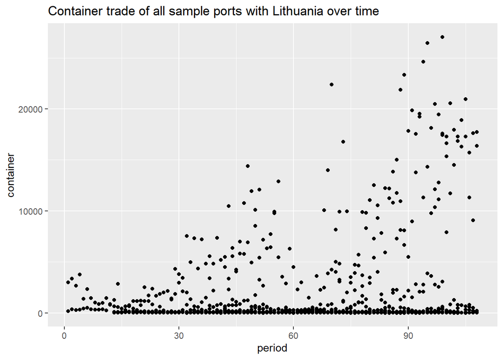

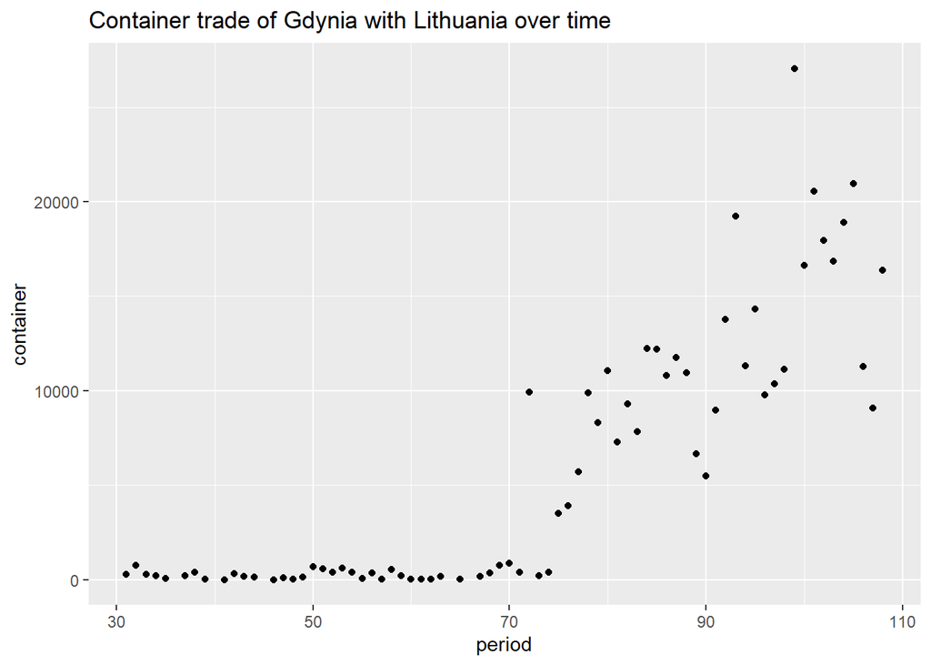

```
##
## Call:
## lm(formula = container ~ treatment * I(period - 100) + cranes +
##     max_lift + cargo_depth + quay_length, data = port_data_gdynia)
##
## Residuals:
##     Min      1Q  Median      3Q     Max
## -6099.7 -2774.3    41.7  2091.4 14630.6
##
## Coefficients: (2 not defined because of singularities)
##                            Estimate Std. Error t value Pr(>|t|)
## (Intercept)               17968.422   6407.016   2.804  0.00659 **
## treatment                  6727.991   2528.202   2.661  0.00974 **
## I(period - 100)             270.318     57.174   4.728 1.21e-05 ***
## cranes                      101.987    408.025   0.250  0.80339
## max_lift                         NA         NA      NA       NA
## cargo_depth                      NA         NA      NA       NA
## quay_length                  -4.380      4.779  -0.916  0.36271
## treatment:I(period - 100)  -972.423    467.568  -2.080  0.04138 *
## ---
## Signif. codes:  0 '***' 0.001 '**' 0.01 '*' 0.05 '.' 0.1 ' ' 1
##
## Residual standard error: 3617 on 67 degrees of freedom
## Multiple R-squared:  0.7467, Adjusted R-squared:  0.7278
## F-statistic: 39.51 on 5 and 67 DF,  p-value: < 2.2e-16
```

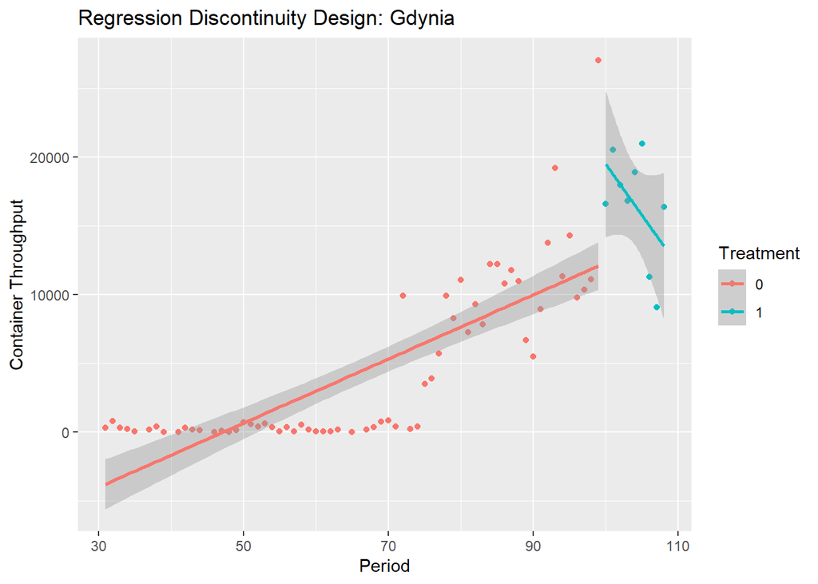

The underlying RDD model is:

$$Y_{t} = \beta_0 + \beta_1 \text{RunningVar}_{t} + \beta_2
\text{Treated}_{t} + \beta_3 (\text{RunningVar}_{t} \times
\text{Treated}_{t}) + \beta \mathbf{X}_{t} + \epsilon_{t}$$

where: - $Y_{t}$ is the container throughput between Gdynia and Lithuania at time t. - $\text{RunningVar}_{t}$ is the running variable defined as the difference between period t and the cutoff period 100. - $\text{Treated}_{it}$ is is a dummy variable that takes the value 1 for periods greater than or equal to 100 and 0 otherwise. - $\mathbf{X}_{t}$ is a vector of control variables. - $\beta_0, \beta_1, \beta_2, \beta_3$ are coefficients. - $\beta$ is a vector of coefficients for the control variables. - $\epsilon_{t}$ is the error term.

We do see a significant jump in the intercept and in the slope in the pre- as compared to the post- treatment period for Gdynia’s trade with Lithuania.

## Gdynia placebo test: setting cutoff fat covid start period 94

```
##
## Call:
## lm(formula = container ~ treatment2 * I(period - 94) + cranes +
##     max_lift + cargo_depth + quay_length, data = port_data_gdynia)
##
## Residuals:
##     Min      1Q  Median      3Q     Max
## -7593.0 -2810.3   105.1  1930.0 11807.3
##
## Coefficients: (2 not defined because of singularities)
##                            Estimate Std. Error t value Pr(>|t|)
## (Intercept)               11692.197   6510.761   1.796  0.07703 .
## treatment2                 5157.397   2202.001   2.342  0.02215 *
## I(period - 94)              191.994     67.699   2.836  0.00604 **
## cranes                      556.606    453.511   1.227  0.22399
## max_lift                         NA         NA      NA       NA
## cargo_depth                      NA         NA      NA       NA
## quay_length                  -6.434      4.812  -1.337  0.18570
## treatment2:I(period - 94)   -20.814    220.974  -0.094  0.92524
## ---
## Signif. codes:  0 '***' 0.001 '**' 0.01 '*' 0.05 '.' 0.1 ' ' 1
##
## Residual standard error: 3597 on 67 degrees of freedom
## Multiple R-squared:  0.7496, Adjusted R-squared:  0.7309
## F-statistic: 40.11 on 5 and 67 DF,  p-value: < 2.2e-16
```

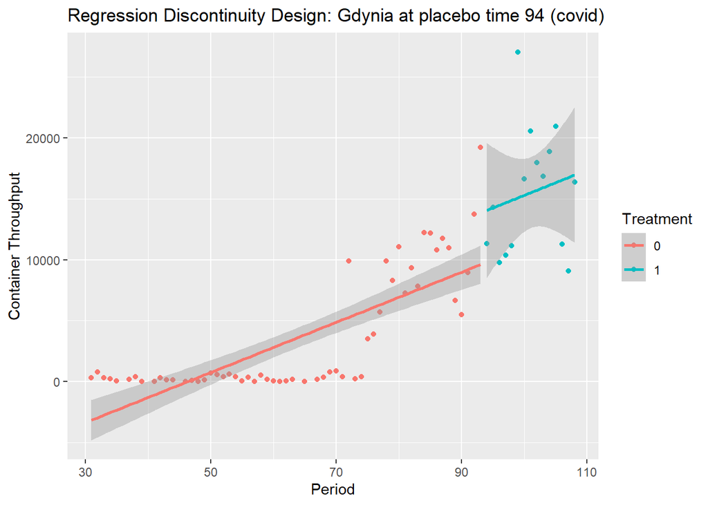

## Restricting Gdynia sample to 90-109 (around the cutoff at 100)

```
##
## Call:
## lm(formula = container ~ treatment * I(period - 100) + cranes +
##     max_lift + cargo_depth + quay_length, data = port_data_gdynia_90)
##
## Residuals:
##     Min      1Q  Median      3Q     Max
## -5849.6 -2968.8  -352.3  2278.0  9613.8
##
## Coefficients: (2 not defined because of singularities)
##                           Estimate Std. Error t value Pr(>|t|)
## (Intercept)               28069.42   95515.80   0.294    0.773
## treatment                   421.20    4938.77   0.085    0.933
## I(period - 100)            1260.87     933.34   1.351    0.200
## cranes                    -3549.80    9014.62  -0.394    0.700
## max_lift                        NA         NA      NA       NA
## cargo_depth                     NA         NA      NA       NA
## quay_length                  24.43      73.13   0.334    0.744
## treatment:I(period - 100) -1738.40    1616.59  -1.075    0.302
##
## Residual standard error: 5112 on 13 degrees of freedom
## Multiple R-squared:  0.341,  Adjusted R-squared:  0.0875
## F-statistic: 1.345 on 5 and 13 DF,  p-value: 0.3063
```

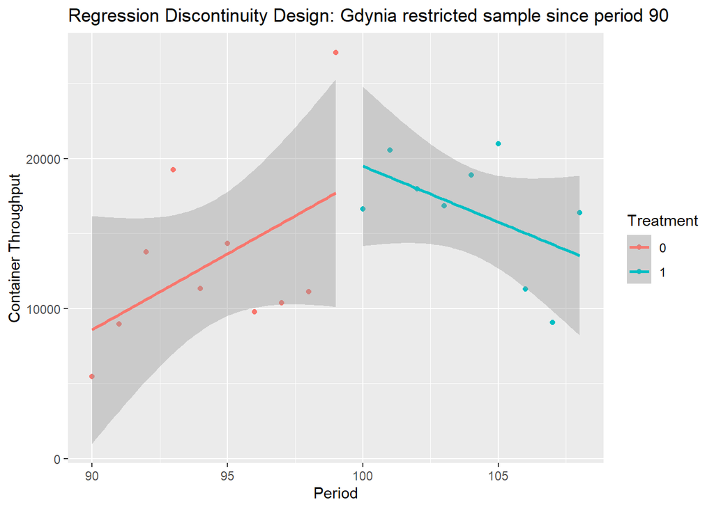

## Using all Chinese-treated ports not just Gdynia

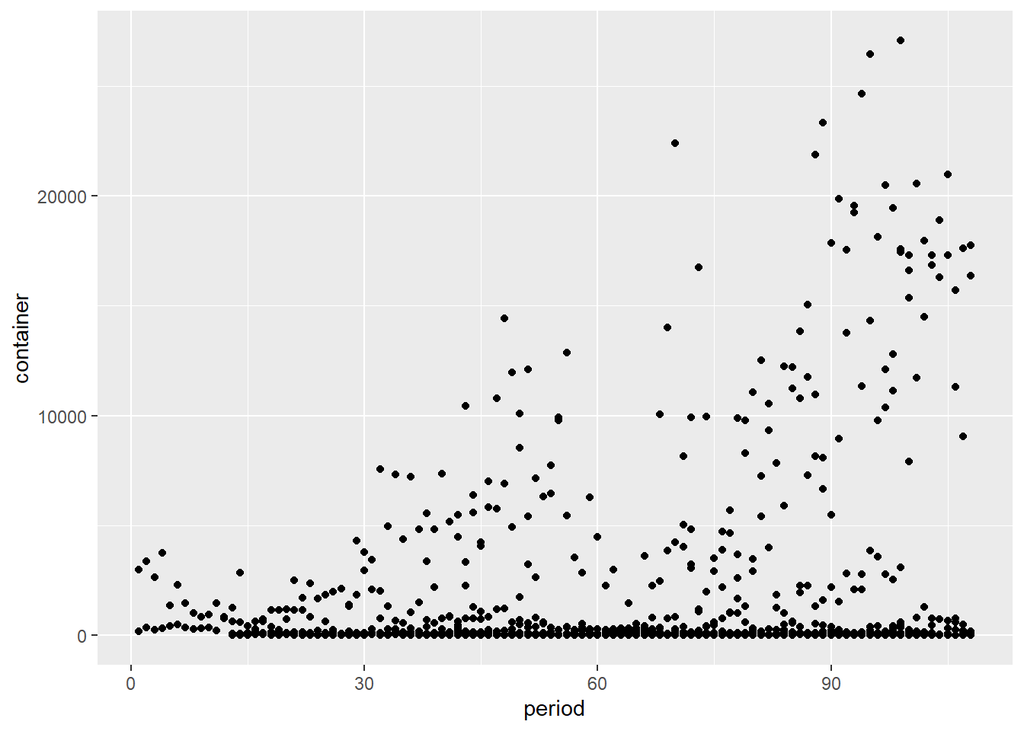

```
##
## Call:
## lm(formula = container ~ treatment * I(period - 100) + factor(port_code),
##     data = port_data_TEU)
##
## Residuals:
##     Min      1Q  Median      3Q     Max
## -8164.1 -1924.3  -211.9  1497.5 18988.8
##
## Coefficients:
##                            Estimate Std. Error t value Pr(>|t|)
## (Intercept)               10407.819    419.246  24.825  < 2e-16 ***
## treatment                   751.980    701.174   1.072  0.28385
## I(period - 100)              76.980      5.239  14.695  < 2e-16 ***
## factor(port_code)BEZEE    -7284.036    607.719 -11.986  < 2e-16 ***
## factor(port_code)ESBCN    -7229.995    464.633 -15.561  < 2e-16 ***
## factor(port_code)ESBIO    -7055.215    513.892 -13.729  < 2e-16 ***
## factor(port_code)ESVLC    -6930.326    463.790 -14.943  < 2e-16 ***
## factor(port_code)FRDKK    -9220.477   1116.676  -8.257 6.40e-16 ***
## factor(port_code)FRLEH    -6237.838    576.552 -10.819  < 2e-16 ***
## factor(port_code)FRMRS    -9780.482   1625.939  -6.015 2.76e-09 ***
## factor(port_code)FRNTE    -8364.636    558.014 -14.990  < 2e-16 ***
## factor(port_code)GRPIR    -8987.868    618.492 -14.532  < 2e-16 ***
## factor(port_code)GRSKG    -9937.942   3179.866  -3.125  0.00184 **
## factor(port_code)ITGOA    -9148.750   1459.261  -6.269 6.01e-10 ***
## factor(port_code)MTMAR    -8047.783    516.749 -15.574  < 2e-16 ***
## factor(port_code)NLAMS    -5767.228    795.760  -7.247 1.03e-12 ***
## factor(port_code)NLMOE    -9583.921    824.595 -11.623  < 2e-16 ***
## factor(port_code)NLRTM       27.469    514.247   0.053  0.95741
## factor(port_code)PLGDY    -2260.652    503.763  -4.488 8.29e-06 ***
## factor(port_code)TRAMB    -8373.521   1242.559  -6.739 3.11e-11 ***
## treatment:I(period - 100)  -167.819    139.762  -1.201  0.23021
## ---
## Signif. codes:  0 '***' 0.001 '**' 0.01 '*' 0.05 '.' 0.1 ' ' 1
##
## Residual standard error: 3155 on 777 degrees of freedom
##   (40 Beobachtungen als fehlend gelöscht)
## Multiple R-squared:  0.5269, Adjusted R-squared:  0.5148
## F-statistic: 43.27 on 20 and 777 DF,  p-value: < 2.2e-16
```

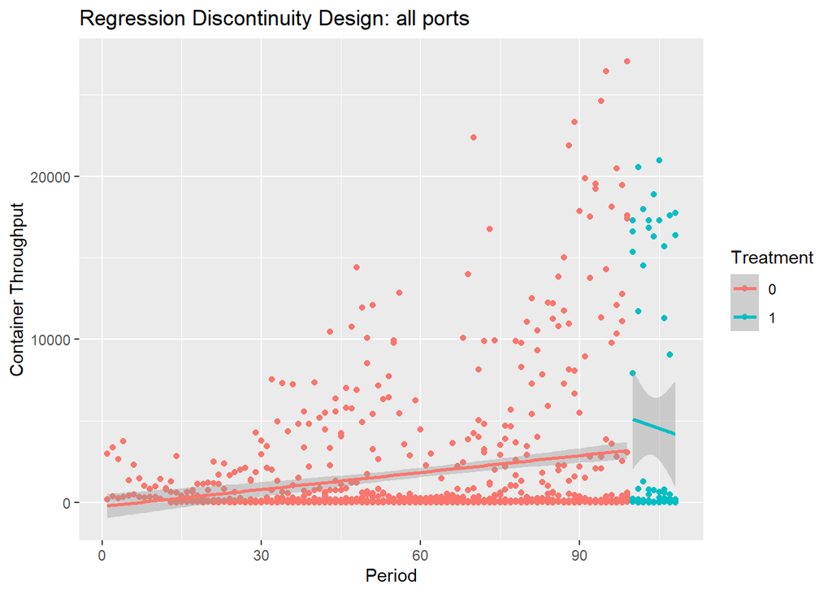

The underlying model that was estimated takes care of changes in the port infrastructure and includes port-dummies. More precisely, we estimate :

$$Y_{it} = \beta_0 + \beta_1 \text{RunningVar}_{it} + \beta_2
\text{Treated}_{it} + \beta_3 (\text{RunningVar}_{it} \times
\text{Treated}_{it}) + \beta \mathbf{X}_{it} + \alpha_i + \epsilon_{it}$$

where: - $Y_{it}$ is the the container throughput between China trated port i and Lithuania at time t. - $\text{RunningVar}_{it}$ is the running variable defined as the difference between period t and the cutoff period 100. - $\text{Treated}_{it}$ is a dummy variable that takes the value 1 for periods greater than or equal to 100 and 0 otherwise. - $\mathbf{X}_{it}$ is a vector of control variables. - $\beta_0, \beta_1, \beta_2, \beta_3$ are coefficients. - $\beta$ is a vector of coefficients for the control variables. - $\alpha_i$ is the individual-specific effect. - $\epsilon_{it}$ is the error term.

The coefficient $\beta_2$ captures the average treatment effect of the policy change at the cutoff period (level effect), while $\beta_3$ captures how this effect varies with the running variable (slope effect).

## RDD with FE using the sample with all Chinese ports

```
## Oneway (individual) effect Within Model
##
## Call:
## plm(formula = container ~ treatment * I(period - 100) + cranes +
##     max_lift + cargo_depth + quay_length, data = port_data_TEU,
##     effect = "individual", model = "within")
##
## Unbalanced Panel: n = 18, T = 1-96, N = 798
##
## Residuals:
##      Min.   1st Qu.    Median   3rd Qu.      Max.
## -10783.72  -1401.83   -282.12   1047.16  19839.04
##
## Coefficients:
##                             Estimate Std. Error t-value  Pr(>|t|)
## treatment                  983.23382  665.15330  1.4782  0.139759
## I(period - 100)             36.89705    6.56765  5.6180 2.694e-08 ***
## cranes                     218.08303   32.75780  6.6574 5.274e-11 ***
## quay_length                 -0.91232    0.32314 -2.8233  0.004875 **
## treatment:I(period - 100) -118.86905  132.21942 -0.8990  0.368917
## ---
## Signif. codes:  0 '***' 0.001 '**' 0.01 '*' 0.05 '.' 0.1 ' ' 1
##
## Total Sum of Squares:    1.0578e+10
## Residual Sum of Squares: 6891100000
## R-Squared:      0.34858
## Adj. R-Squared: 0.33008
## F-statistic: 82.9403 on 5 and 775 DF, p-value: < 2.22e-16
```

When using a panel RDD estimator that uses within variation only, we get similar estimates.

A positive jump of the intercept at 100 and then a downwards sloping line that is however insignificant. Suggesting that there is no overall effect of all treated ports but that it is rather Gdynia that drives the outcome.

## Checking other ports trade development with Lituania

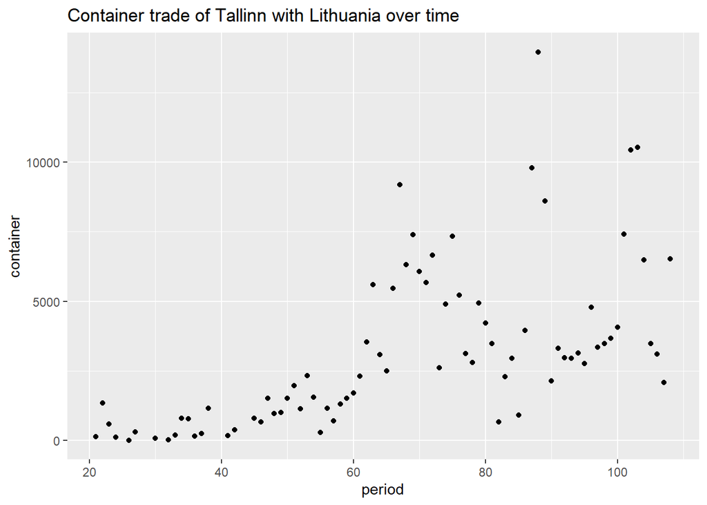

```
##
## Call:
## lm(formula = container ~ treatment * I(period - 100) + cranes +
##     max_lift + cargo_depth + quay_length, data = port_data_Tallinn)
##
## Residuals:
##     Min      1Q  Median      3Q     Max
## -4010.5 -1234.4  -169.9   645.0  9203.6
##
## Coefficients: (2 not defined because of singularities)
##                           Estimate Std. Error t value Pr(>|t|)
## (Intercept)               5645.023   3166.594   1.783  0.07874 .
## treatment                 4376.628   1533.982   2.853  0.00561 **
## I(period - 100)             12.494     20.131   0.621  0.53674
## cranes                    3326.054    905.524   3.673  0.00045 ***
## max_lift                        NA         NA      NA       NA
## cargo_depth                     NA         NA      NA       NA
## quay_length                -26.790      8.157  -3.284  0.00156 **
## treatment:I(period - 100)  -67.875    459.647  -0.148  0.88301
## ---
## Signif. codes:  0 '***' 0.001 '**' 0.01 '*' 0.05 '.' 0.1 ' ' 1
##
## Residual standard error: 2119 on 74 degrees of freedom
## Multiple R-squared:  0.5085, Adjusted R-squared:  0.4753
## F-statistic: 15.31 on 5 and 74 DF,  p-value: 2.59e-10
```

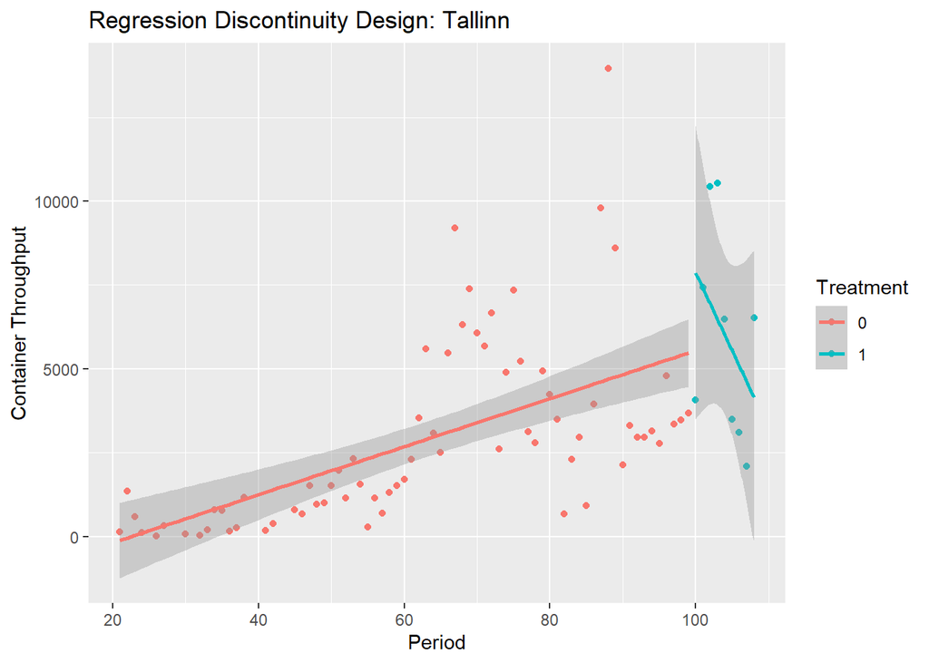

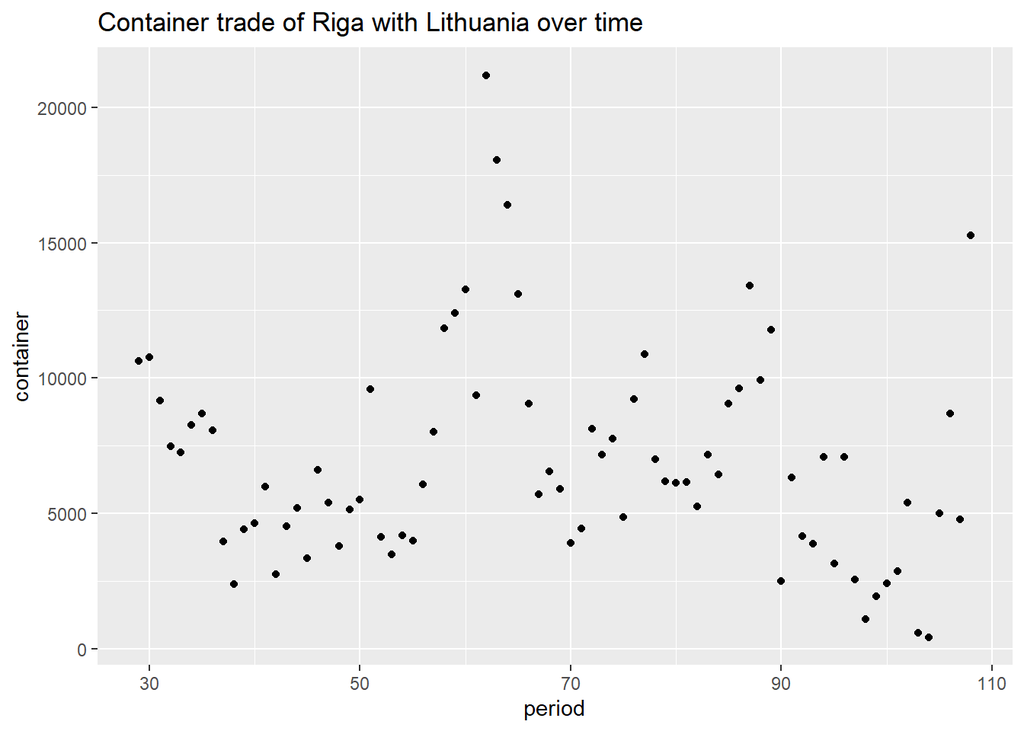

```
##
## Call:
## lm(formula = container ~ treatment * I(period - 100) + cranes +
##     max_lift + cargo_depth + quay_length, data = port_data_Riga)
##
## Residuals:
##     Min      1Q  Median      3Q     Max
## -5642.5 -2175.7  -396.7  1503.7 11411.1
##
## Coefficients: (3 not defined because of singularities)
##                            Estimate Std. Error t value Pr(>|t|)
## (Intercept)               -27543.26    8697.49  -3.167 0.002229 **
## treatment                  -5785.57    2294.16  -2.522 0.013795 *
## I(period - 100)             -218.68      56.13  -3.896 0.000211 ***
## cranes                      2417.10     609.29   3.967 0.000165 ***
## max_lift                         NA         NA      NA       NA
## cargo_depth                      NA         NA      NA       NA
## quay_length                      NA         NA      NA       NA
## treatment:I(period - 100)   1353.70     451.70   2.997 0.003696 **
## ---
## Signif. codes:  0 '***' 0.001 '**' 0.01 '*' 0.05 '.' 0.1 ' ' 1
##
## Residual standard error: 3472 on 75 degrees of freedom
## Multiple R-squared:  0.2535, Adjusted R-squared:  0.2137
## F-statistic: 6.368 on 4 and 75 DF,  p-value: 0.0001819
```

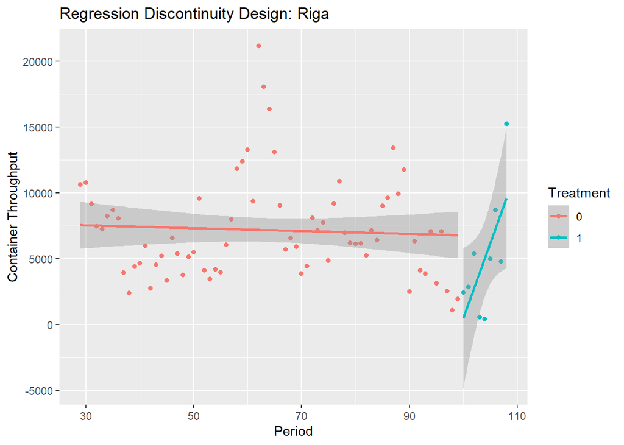

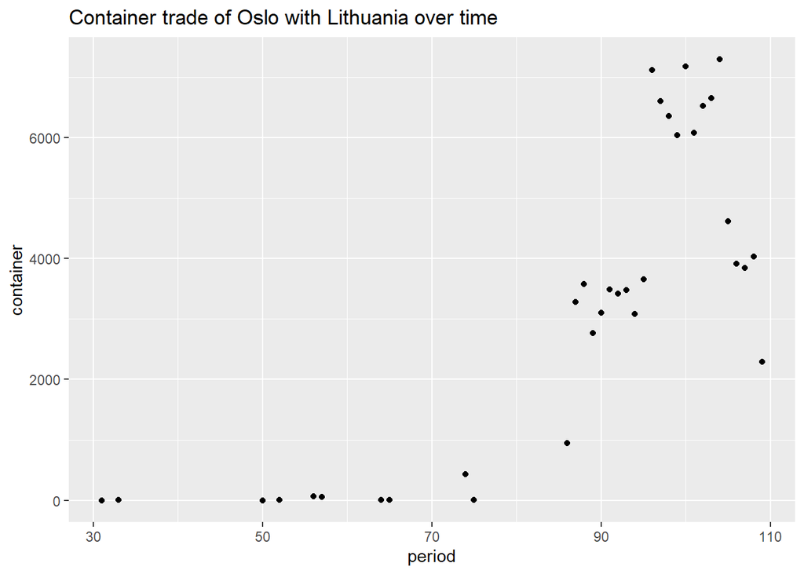

```
##
## Call:
## lm(formula = container ~ treatment * I(period - 100) + cranes +
##     max_lift + cargo_depth + quay_length, data = port_data_Oslo)
##
## Residuals:
##     Min      1Q  Median      3Q     Max
## -1905.7  -735.8  -145.5   434.3  2457.2
##
## Coefficients: (2 not defined because of singularities)
##                            Estimate Std. Error t value Pr(>|t|)
## (Intercept)               13980.238   2361.149   5.921 2.61e-06 ***
## treatment                  2083.309    748.116   2.785 0.009671 **
## I(period - 100)             150.001     17.053   8.796 2.06e-09 ***
## cranes                      -33.074    843.933  -0.039 0.969027
## max_lift                         NA         NA      NA       NA
## cargo_depth                      NA         NA      NA       NA
## quay_length                 -13.012      4.972  -2.617 0.014360 *
## treatment:I(period - 100)  -592.951    138.021  -4.296 0.000201 ***
## ---
## Signif. codes:  0 '***' 0.001 '**' 0.01 '*' 0.05 '.' 0.1 ' ' 1
##
## Residual standard error: 1061 on 27 degrees of freedom
##   (1 Beobachtung als fehlend gelöscht)
## Multiple R-squared:   0.86,  Adjusted R-squared:  0.8341
## F-statistic: 33.18 on 5 and 27 DF,  p-value: 1.024e-10
```

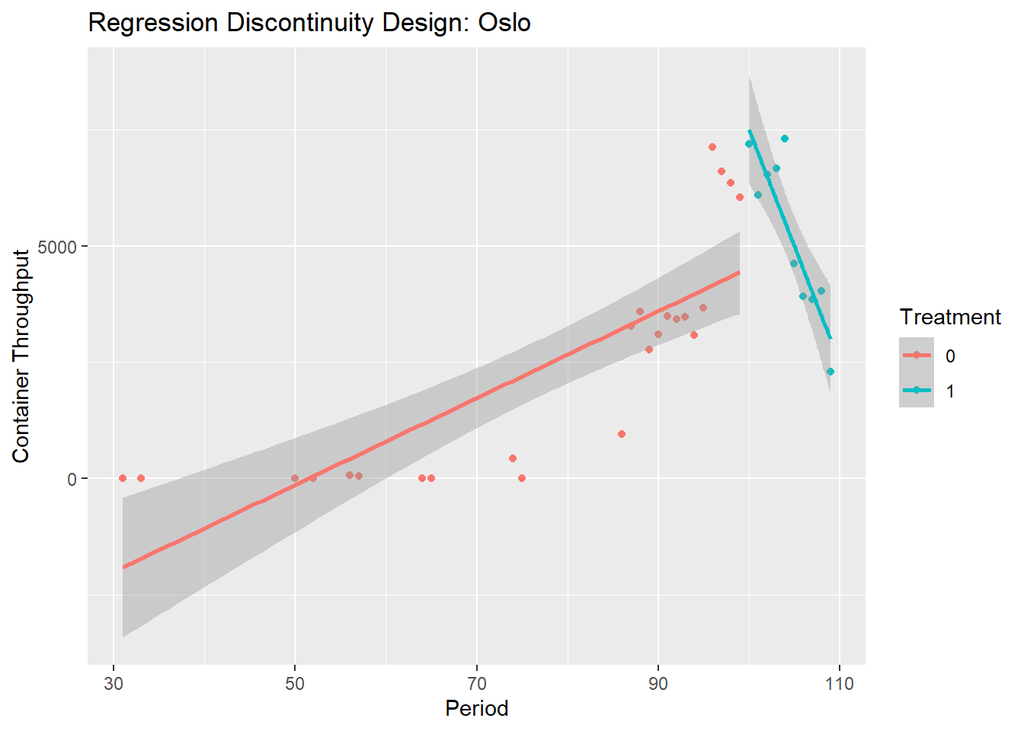

Tallinn, Riga, Oslo are geographically close and have a similar average trade volume with Lithuania as compared to Gdynia.

Tallinn shows a similar behavior as Gdynia. Its post-treatment slope coefficient is negative too but insignificant. Oslo too is similar and shows a significant negative slope after treatement. Riga behaves very differently to Gdynia and Oslo.

The results alltogether suggest that Gdynia did reduce its trade to Lithuania after the diplomatic dispute between China and Lithuania. It is the only Chinese-treated port to do so. It also behaves differently than the average comparable non-treated port in the sample but it does not behave differently to single other comparable ports in the region, especially Tallinn, and Oslo.

The policy effect may be one that goes without port ownership by Chinese but by simply restricting trade with Lithuania that hits those ports more that are heavily involved in trade with Lithuanian ports.

# Event Study

Upcoming on July 18/19 …